# Optimal Treatment Analysis

## Outcome Variable

**Outcome Variable:** ever_stunted

## Predictor Variables

**Intervention Variable:** parity

**Adjustment Set:**

- arm
- W_mage
- meducyrs
- feducyrs
- hhwealth_quart
- W_mhtcm
- vagbrth
- W_nrooms
- impsan
- delta_W_mage
- delta_meducyrs
- delta_feducyrs
- delta_hhwealth_quart
- delta_W_mhtcm
- delta_vagbrth
- delta_W_nrooms
- delta_impsan

## Stratifying Variables

The analysis was stratified on these variable(s):

- agecat
- studyid
- country

## Data Summary

| agecat | studyid | country | parity | ever_stunted | n_cell | n |
| --- | --- | --- | --- | --- | --- | --- |
| 0-24 months | ki1000304b-SAS-CompFeed | INDIA | 1 | 0 | 162 | 1533 |
| 0-24 months | ki1000304b-SAS-CompFeed | INDIA | 1 | 1 | 290 | 1533 |
| 0-24 months | ki1000304b-SAS-CompFeed | INDIA | 2 | 0 | 122 | 1533 |
| 0-24 months | ki1000304b-SAS-CompFeed | INDIA | 2 | 1 | 238 | 1533 |
| 0-24 months | ki1000304b-SAS-CompFeed | INDIA | 3+ | 0 | 189 | 1533 |
| 0-24 months | ki1000304b-SAS-CompFeed | INDIA | 3+ | 1 | 532 | 1533 |
| 0-24 months | ki1000304b-SAS-FoodSuppl | INDIA | 1 | 0 | 19 | 397 |
| 0-24 months | ki1000304b-SAS-FoodSuppl | INDIA | 1 | 1 | 58 | 397 |
| 0-24 months | ki1000304b-SAS-FoodSuppl | INDIA | 2 | 0 | 12 | 397 |
| 0-24 months | ki1000304b-SAS-FoodSuppl | INDIA | 2 | 1 | 80 | 397 |
| 0-24 months | ki1000304b-SAS-FoodSuppl | INDIA | 3+ | 0 | 28 | 397 |
| 0-24 months | ki1000304b-SAS-FoodSuppl | INDIA | 3+ | 1 | 200 | 397 |
| 0-24 months | ki1017093b-PROVIDE | BANGLADESH | 1 | 0 | 154 | 700 |
| 0-24 months | ki1017093b-PROVIDE | BANGLADESH | 1 | 1 | 117 | 700 |
| 0-24 months | ki1017093b-PROVIDE | BANGLADESH | 2 | 0 | 134 | 700 |
| 0-24 months | ki1017093b-PROVIDE | BANGLADESH | 2 | 1 | 110 | 700 |
| 0-24 months | ki1017093b-PROVIDE | BANGLADESH | 3+ | 0 | 108 | 700 |
| 0-24 months | ki1017093b-PROVIDE | BANGLADESH | 3+ | 1 | 77 | 700 |
| 0-24 months | ki1066203-TanzaniaChild2 | TANZANIA, UNITED REPUBLIC OF | 1 | 0 | 550 | 2357 |
| 0-24 months | ki1066203-TanzaniaChild2 | TANZANIA, UNITED REPUBLIC OF | 1 | 1 | 271 | 2357 |
| 0-24 months | ki1066203-TanzaniaChild2 | TANZANIA, UNITED REPUBLIC OF | 2 | 0 | 494 | 2357 |
| 0-24 months | ki1066203-TanzaniaChild2 | TANZANIA, UNITED REPUBLIC OF | 2 | 1 | 277 | 2357 |
| 0-24 months | ki1066203-TanzaniaChild2 | TANZANIA, UNITED REPUBLIC OF | 3+ | 0 | 495 | 2357 |
| 0-24 months | ki1066203-TanzaniaChild2 | TANZANIA, UNITED REPUBLIC OF | 3+ | 1 | 270 | 2357 |
| 0-24 months | ki1101329-Keneba | GAMBIA | 1 | 0 | 119 | 1990 |
| 0-24 months | ki1101329-Keneba | GAMBIA | 1 | 1 | 122 | 1990 |
| 0-24 months | ki1101329-Keneba | GAMBIA | 2 | 0 | 110 | 1990 |
| 0-24 months | ki1101329-Keneba | GAMBIA | 2 | 1 | 104 | 1990 |
| 0-24 months | ki1101329-Keneba | GAMBIA | 3+ | 0 | 632 | 1990 |
| 0-24 months | ki1101329-Keneba | GAMBIA | 3+ | 1 | 903 | 1990 |

[output cut: 168 more lines]

The following strata were considered:

- agecat: 0-24 months, studyid: ki1000304b-SAS-CompFeed, country: INDIA
- agecat: 0-24 months, studyid: ki1000304b-SAS-FoodSuppl, country: INDIA
- agecat: 0-24 months, studyid: ki1017093b-PROVIDE, country: BANGLADESH
- agecat: 0-24 months, studyid: ki1066203-TanzaniaChild2, country: TANZANIA, UNITED REPUBLIC OF
- agecat: 0-24 months, studyid: ki1101329-Keneba, country: GAMBIA
- agecat: 0-24 months, studyid: ki1113344-GMS-Nepal, country: NEPAL
- agecat: 0-24 months, studyid: ki1126311-ZVITAMBO, country: ZIMBABWE
- agecat: 0-24 months, studyid: ki1135781-COHORTS, country: GUATEMALA
- agecat: 0-24 months, studyid: ki1135781-COHORTS, country: INDIA
- agecat: 0-24 months, studyid: ki1135781-COHORTS, country: PHILIPPINES
- agecat: 0-24 months, studyid: kiGH5241-JiVitA-3, country: BANGLADESH
- agecat: 0-6 months, studyid: ki1000304b-SAS-CompFeed, country: INDIA
- agecat: 0-6 months, studyid: ki1000304b-SAS-FoodSuppl, country: INDIA
- agecat: 0-6 months, studyid: ki1017093b-PROVIDE, country: BANGLADESH
- agecat: 0-6 months, studyid: ki1066203-TanzaniaChild2, country: TANZANIA, UNITED REPUBLIC OF
- agecat: 0-6 months, studyid: ki1101329-Keneba, country: GAMBIA
- agecat: 0-6 months, studyid: ki1113344-GMS-Nepal, country: NEPAL
- agecat: 0-6 months, studyid: ki1126311-ZVITAMBO, country: ZIMBABWE
- agecat: 0-6 months, studyid: ki1135781-COHORTS, country: GUATEMALA
- agecat: 0-6 months, studyid: ki1135781-COHORTS, country: INDIA
- agecat: 0-6 months, studyid: ki1135781-COHORTS, country: PHILIPPINES
- agecat: 0-6 months, studyid: kiGH5241-JiVitA-3, country: BANGLADESH
- agecat: 6-24 months, studyid: ki1000304b-SAS-CompFeed, country: INDIA
- agecat: 6-24 months, studyid: ki1000304b-SAS-FoodSuppl, country: INDIA
- agecat: 6-24 months, studyid: ki1017093b-PROVIDE, country: BANGLADESH
- agecat: 6-24 months, studyid: ki1066203-TanzaniaChild2, country: TANZANIA, UNITED REPUBLIC OF
- agecat: 6-24 months, studyid: ki1101329-Keneba, country: GAMBIA
- agecat: 6-24 months, studyid: ki1113344-GMS-Nepal, country: NEPAL
- agecat: 6-24 months, studyid: ki1126311-ZVITAMBO, country: ZIMBABWE
- agecat: 6-24 months, studyid: ki1135781-COHORTS, country: GUATEMALA
- agecat: 6-24 months, studyid: ki1135781-COHORTS, country: INDIA
- agecat: 6-24 months, studyid: ki1135781-COHORTS, country: PHILIPPINES
- agecat: 6-24 months, studyid: kiGH5241-JiVitA-3, country: BANGLADESH

## Methods Detail

We’re interested in the causal parameters $E[Y_a]$ for all values of $a \in \mathcal{A}$. These parameters represent the mean outcome if, possibly contrary to fact, we intervened to set all units to have $A=a$. Under the randomization and positivity assumptions, these are identified by the statistical parameters $\psi_a=E_W[E_{Y|A,W}(Y|A=a,W)]$. In addition, we’re interested in the mean of $Y$, $E[Y]$ under no intervention (the observed mean). We will estimate these parameters by using SuperLearner to fit the relevant likelihood factors – $E_{Y|A,W}(Y|A=a,W)$ and $p(A=a|W)$, and then updating our likelihood fit using a joint TMLE.

For unadjusted analyses ($W=\{\}$), initial likelihoods were estimated using Lrnr_glm to estimate the simple $E(Y|A)$ and Lrnr_mean to estimate $p(A)$. For adjusted analyses, a small library containing Lrnr_glmnet, Lrnr_xgboost, and Lrnr_mean was used.

Having estimated these parameters, we will then use the delta method to estimate relative risks and attributable risks relative to a prespecified baseline level of $A$.

# Results Detail

## Results Plots

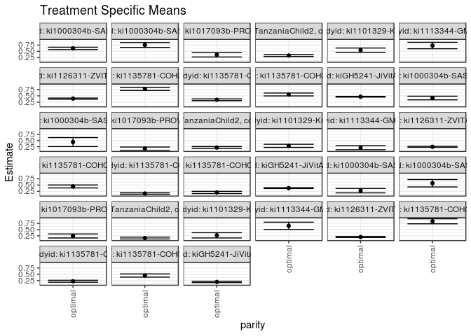

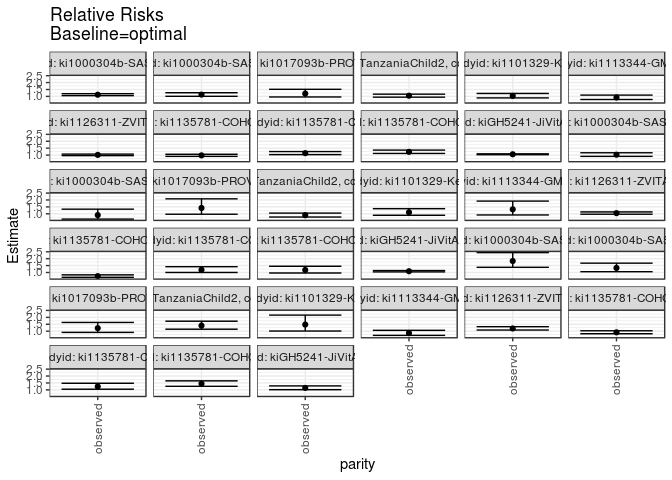

## Results Table

### Parameter: TSM

| agecat | studyid | country | intervention_level | baseline_level | estimate | ci_lower | ci_upper |
| --- | --- | --- | --- | --- | --- | --- | --- |
| 0-24 months | ki1000304b-SAS-CompFeed | INDIA | optimal | NA | 0.6159114 | 0.5677194 | 0.6641033 |
| 0-24 months | ki1000304b-SAS-FoodSuppl | INDIA | optimal | NA | 0.7535793 | 0.6554449 | 0.8517138 |
| 0-24 months | ki1017093b-PROVIDE | BANGLADESH | optimal | NA | 0.3601262 | 0.2712872 | 0.4489651 |
| 0-24 months | ki1066203-TanzaniaChild2 | TANZANIA, UNITED REPUBLIC OF | optimal | NA | 0.3307587 | 0.2918155 | 0.3697018 |
| 0-24 months | ki1101329-Keneba | GAMBIA | optimal | NA | 0.5455979 | 0.4603571 | 0.6308387 |
| 0-24 months | ki1113344-GMS-Nepal | NEPAL | optimal | NA | 0.7310970 | 0.6017802 | 0.8604138 |
| 0-24 months | ki1126311-ZVITAMBO | ZIMBABWE | optimal | NA | 0.3902157 | 0.3680979 | 0.4123336 |
| 0-24 months | ki1135781-COHORTS | GUATEMALA | optimal | NA | 0.7794570 | 0.7154752 | 0.8434389 |
| 0-24 months | ki1135781-COHORTS | INDIA | optimal | NA | 0.3431550 | 0.3075515 | 0.3787586 |
| 0-24 months | ki1135781-COHORTS | PHILIPPINES | optimal | NA | 0.5558672 | 0.4982979 | 0.6134366 |
| 0-24 months | kiGH5241-JiVitA-3 | BANGLADESH | optimal | NA | 0.4660982 | 0.4509320 | 0.4812645 |
| 0-6 months | ki1000304b-SAS-CompFeed | INDIA | optimal | NA | 0.4133188 | 0.3395947 | 0.4870428 |
| 0-6 months | ki1000304b-SAS-FoodSuppl | INDIA | optimal | NA | 0.4352320 | 0.2546213 | 0.6158426 |
| 0-6 months | ki1017093b-PROVIDE | BANGLADESH | optimal | NA | 0.1680378 | 0.0997620 | 0.2363136 |
| 0-6 months | ki1066203-TanzaniaChild2 | TANZANIA, UNITED REPUBLIC OF | optimal | NA | 0.2171045 | 0.1779402 | 0.2562687 |
| 0-6 months | ki1101329-Keneba | GAMBIA | optimal | NA | 0.2834307 | 0.2203951 | 0.3464662 |
| 0-6 months | ki1113344-GMS-Nepal | NEPAL | optimal | NA | 0.2095871 | 0.1272378 | 0.2919364 |
| 0-6 months | ki1126311-ZVITAMBO | ZIMBABWE | optimal | NA | 0.2462590 | 0.2255423 | 0.2669758 |
| 0-6 months | ki1135781-COHORTS | GUATEMALA | optimal | NA | 0.4431143 | 0.3842509 | 0.5019778 |
| 0-6 months | ki1135781-COHORTS | INDIA | optimal | NA | 0.1597290 | 0.1300470 | 0.1894111 |
| 0-6 months | ki1135781-COHORTS | PHILIPPINES | optimal | NA | 0.2023127 | 0.1586329 | 0.2459924 |
| 0-6 months | kiGH5241-JiVitA-3 | BANGLADESH | optimal | NA | 0.3771811 | 0.3598294 | 0.3945329 |
| 6-24 months | ki1000304b-SAS-CompFeed | INDIA | optimal | NA | 0.2748848 | 0.1858527 | 0.3639169 |
| 6-24 months | ki1000304b-SAS-FoodSuppl | INDIA | optimal | NA | 0.5728445 | 0.4251621 | 0.7205270 |
| 6-24 months | ki1017093b-PROVIDE | BANGLADESH | optimal | NA | 0.2458154 | 0.1658866 | 0.3257443 |
| 6-24 months | ki1066203-TanzaniaChild2 | TANZANIA, UNITED REPUBLIC OF | optimal | NA | 0.1623307 | 0.1254537 | 0.1992078 |
| 6-24 months | ki1101329-Keneba | GAMBIA | optimal | NA | 0.2715140 | 0.1665650 | 0.3764630 |
| 6-24 months | ki1113344-GMS-Nepal | NEPAL | optimal | NA | 0.6532704 | 0.5076692 | 0.7988716 |
| 6-24 months | ki1126311-ZVITAMBO | ZIMBABWE | optimal | NA | 0.2055435 | 0.1832317 | 0.2278552 |
| 6-24 months | ki1135781-COHORTS | GUATEMALA | optimal | NA | 0.8342122 | 0.7335335 | 0.9348908 |
| 6-24 months | ki1135781-COHORTS | INDIA | optimal | NA | 0.2173867 | 0.1781648 | 0.2566085 |
| 6-24 months | ki1135781-COHORTS | PHILIPPINES | optimal | NA | 0.4473012 | 0.3835986 | 0.5110037 |
| 6-24 months | kiGH5241-JiVitA-3 | BANGLADESH | optimal | NA | 0.1901941 | 0.1663877 | 0.2140005 |

### Parameter: E(Y)

| agecat | studyid | country | intervention_level | baseline_level | estimate | ci_lower | ci_upper |
| --- | --- | --- | --- | --- | --- | --- | --- |
| 0-24 months | ki1000304b-SAS-CompFeed | INDIA | observed | NA | 0.6914547 | 0.6510509 | 0.7318584 |
| 0-24 months | ki1000304b-SAS-FoodSuppl | INDIA | observed | NA | 0.8513854 | 0.8163510 | 0.8864198 |
| 0-24 months | ki1017093b-PROVIDE | BANGLADESH | observed | NA | 0.4342857 | 0.3975409 | 0.4710305 |
| 0-24 months | ki1066203-TanzaniaChild2 | TANZANIA, UNITED REPUBLIC OF | observed | NA | 0.3470513 | 0.3278294 | 0.3662733 |
| 0-24 months | ki1101329-Keneba | GAMBIA | observed | NA | 0.5673367 | 0.5455633 | 0.5891101 |
| 0-24 months | ki1113344-GMS-Nepal | NEPAL | observed | NA | 0.6744186 | 0.6369554 | 0.7118819 |
| 0-24 months | ki1126311-ZVITAMBO | ZIMBABWE | observed | NA | 0.3966032 | 0.3885203 | 0.4046860 |
| 0-24 months | ki1135781-COHORTS | GUATEMALA | observed | NA | 0.7639706 | 0.7413939 | 0.7865473 |
| 0-24 months | ki1135781-COHORTS | INDIA | observed | NA | 0.3911447 | 0.3770865 | 0.4052029 |
| 0-24 months | ki1135781-COHORTS | PHILIPPINES | observed | NA | 0.6863963 | 0.6699497 | 0.7028430 |
| 0-24 months | kiGH5241-JiVitA-3 | BANGLADESH | observed | NA | 0.4938812 | 0.4860382 | 0.5017241 |
| 0-6 months | ki1000304b-SAS-CompFeed | INDIA | observed | NA | 0.4254902 | 0.3977202 | 0.4532601 |
| 0-6 months | ki1000304b-SAS-FoodSuppl | INDIA | observed | NA | 0.3939394 | 0.3457532 | 0.4421255 |
| 0-6 months | ki1017093b-PROVIDE | BANGLADESH | observed | NA | 0.2385714 | 0.2069753 | 0.2701675 |
| 0-6 months | ki1066203-TanzaniaChild2 | TANZANIA, UNITED REPUBLIC OF | observed | NA | 0.1947391 | 0.1787488 | 0.2107293 |
| 0-6 months | ki1101329-Keneba | GAMBIA | observed | NA | 0.3135456 | 0.2924164 | 0.3346748 |
| 0-6 months | ki1113344-GMS-Nepal | NEPAL | observed | NA | 0.2774086 | 0.2416141 | 0.3132032 |
| 0-6 months | ki1126311-ZVITAMBO | ZIMBABWE | observed | NA | 0.2580071 | 0.2507721 | 0.2652422 |
| 0-6 months | ki1135781-COHORTS | GUATEMALA | observed | NA | 0.3253896 | 0.2975756 | 0.3532035 |
| 0-6 months | ki1135781-COHORTS | INDIA | observed | NA | 0.1902526 | 0.1787489 | 0.2017563 |
| 0-6 months | ki1135781-COHORTS | PHILIPPINES | observed | NA | 0.2390451 | 0.2239262 | 0.2541640 |
| 0-6 months | kiGH5241-JiVitA-3 | BANGLADESH | observed | NA | 0.4108676 | 0.4034192 | 0.4183159 |
| 6-24 months | ki1000304b-SAS-CompFeed | INDIA | observed | NA | 0.5030750 | 0.4588491 | 0.5473009 |
| 6-24 months | ki1000304b-SAS-FoodSuppl | INDIA | observed | NA | 0.7615063 | 0.7073642 | 0.8156483 |
| 6-24 months | ki1017093b-PROVIDE | BANGLADESH | observed | NA | 0.2997812 | 0.2577294 | 0.3418330 |
| 6-24 months | ki1066203-TanzaniaChild2 | TANZANIA, UNITED REPUBLIC OF | observed | NA | 0.2276474 | 0.2069456 | 0.2483493 |
| 6-24 months | ki1101329-Keneba | GAMBIA | observed | NA | 0.4014652 | 0.3754511 | 0.4274793 |
| 6-24 months | ki1113344-GMS-Nepal | NEPAL | observed | NA | 0.5610329 | 0.5138522 | 0.6082135 |
| 6-24 months | ki1126311-ZVITAMBO | ZIMBABWE | observed | NA | 0.2458522 | 0.2363900 | 0.2553144 |
| 6-24 months | ki1135781-COHORTS | GUATEMALA | observed | NA | 0.7642458 | 0.7364214 | 0.7920702 |
| 6-24 months | ki1135781-COHORTS | INDIA | observed | NA | 0.2705750 | 0.2559548 | 0.2851951 |
| 6-24 months | ki1135781-COHORTS | PHILIPPINES | observed | NA | 0.6449788 | 0.6246093 | 0.6653483 |
| 6-24 months | kiGH5241-JiVitA-3 | BANGLADESH | observed | NA | 0.2172797 | 0.2079084 | 0.2266510 |

### Parameter: RR

| agecat | studyid | country | intervention_level | baseline_level | estimate | ci_lower | ci_upper |
| --- | --- | --- | --- | --- | --- | --- | --- |
| 0-24 months | ki1000304b-SAS-CompFeed | INDIA | observed | optimal | 1.1226529 | 1.0547253 | 1.1949553 |
| 0-24 months | ki1000304b-SAS-FoodSuppl | INDIA | observed | optimal | 1.1297886 | 1.0085263 | 1.2656312 |
| 0-24 months | ki1017093b-PROVIDE | BANGLADESH | observed | optimal | 1.2059266 | 0.9596955 | 1.5153337 |
| 0-24 months | ki1066203-TanzaniaChild2 | TANZANIA, UNITED REPUBLIC OF | observed | optimal | 1.0492585 | 0.9464088 | 1.1632853 |
| 0-24 months | ki1101329-Keneba | GAMBIA | observed | optimal | 1.0398440 | 0.8922537 | 1.2118476 |
| 0-24 months | ki1113344-GMS-Nepal | NEPAL | observed | optimal | 0.9224748 | 0.7774523 | 1.0945493 |
| 0-24 months | ki1126311-ZVITAMBO | ZIMBABWE | observed | optimal | 1.0163690 | 0.9640830 | 1.0714907 |
| 0-24 months | ki1135781-COHORTS | GUATEMALA | observed | optimal | 0.9801317 | 0.9069755 | 1.0591887 |
| 0-24 months | ki1135781-COHORTS | INDIA | observed | optimal | 1.1398484 | 1.0359849 | 1.2541248 |
| 0-24 months | ki1135781-COHORTS | PHILIPPINES | observed | optimal | 1.2348206 | 1.1188338 | 1.3628316 |
| 0-24 months | kiGH5241-JiVitA-3 | BANGLADESH | observed | optimal | 1.0596074 | 1.0292199 | 1.0908921 |
| 0-6 months | ki1000304b-SAS-CompFeed | INDIA | observed | optimal | 1.0294480 | 0.9075338 | 1.1677396 |
| 0-6 months | ki1000304b-SAS-FoodSuppl | INDIA | observed | optimal | 0.9051252 | 0.6133584 | 1.3356818 |
| 0-6 months | ki1017093b-PROVIDE | BANGLADESH | observed | optimal | 1.4197489 | 0.9684362 | 2.0813834 |
| 0-6 months | ki1066203-TanzaniaChild2 | TANZANIA, UNITED REPUBLIC OF | observed | optimal | 0.8969832 | 0.7651435 | 1.0515398 |
| 0-6 months | ki1101329-Keneba | GAMBIA | observed | optimal | 1.1062515 | 0.8925506 | 1.3711181 |
| 0-6 months | ki1113344-GMS-Nepal | NEPAL | observed | optimal | 1.3235960 | 0.9130896 | 1.9186575 |
| 0-6 months | ki1126311-ZVITAMBO | ZIMBABWE | observed | optimal | 1.0477062 | 0.9679140 | 1.1340762 |
| 0-6 months | ki1135781-COHORTS | GUATEMALA | observed | optimal | 0.7343241 | 0.6514364 | 0.8277584 |
| 0-6 months | ki1135781-COHORTS | INDIA | observed | optimal | 1.1910960 | 1.0007911 | 1.4175883 |
| 0-6 months | ki1135781-COHORTS | PHILIPPINES | observed | optimal | 1.1815629 | 0.9626554 | 1.4502498 |
| 0-6 months | kiGH5241-JiVitA-3 | BANGLADESH | observed | optimal | 1.0893110 | 1.0433219 | 1.1373274 |
| 6-24 months | ki1000304b-SAS-CompFeed | INDIA | observed | optimal | 1.8301302 | 1.3752031 | 2.4355505 |
| 6-24 months | ki1000304b-SAS-FoodSuppl | INDIA | observed | optimal | 1.3293420 | 1.0561655 | 1.6731754 |
| 6-24 months | ki1017093b-PROVIDE | BANGLADESH | observed | optimal | 1.2195377 | 0.9106363 | 1.6332230 |
| 6-24 months | ki1066203-TanzaniaChild2 | TANZANIA, UNITED REPUBLIC OF | observed | optimal | 1.4023680 | 1.1421586 | 1.7218589 |
| 6-24 months | ki1101329-Keneba | GAMBIA | observed | optimal | 1.4786170 | 1.0111935 | 2.1621067 |
| 6-24 months | ki1113344-GMS-Nepal | NEPAL | observed | optimal | 0.8588065 | 0.6950674 | 1.0611181 |
| 6-24 months | ki1126311-ZVITAMBO | ZIMBABWE | observed | optimal | 1.1961079 | 1.0813999 | 1.3229834 |
| 6-24 months | ki1135781-COHORTS | GUATEMALA | observed | optimal | 0.9161288 | 0.8142026 | 1.0308147 |
| 6-24 months | ki1135781-COHORTS | INDIA | observed | optimal | 1.2446715 | 1.0487829 | 1.4771475 |
| 6-24 months | ki1135781-COHORTS | PHILIPPINES | observed | optimal | 1.4419341 | 1.2592996 | 1.6510558 |
| 6-24 months | kiGH5241-JiVitA-3 | BANGLADESH | observed | optimal | 1.1424105 | 1.0143539 | 1.2866337 |

### Parameter: PAR

| agecat | studyid | country | intervention_level | baseline_level | estimate | ci_lower | ci_upper |
| --- | --- | --- | --- | --- | --- | --- | --- |
| 0-24 months | ki1000304b-SAS-CompFeed | INDIA | optimal | NA | 0.0755433 | 0.0361415 | 0.1149451 |
| 0-24 months | ki1000304b-SAS-FoodSuppl | INDIA | optimal | NA | 0.0978060 | 0.0131771 | 0.1824350 |
| 0-24 months | ki1017093b-PROVIDE | BANGLADESH | optimal | NA | 0.0741596 | -0.0080788 | 0.1563979 |
| 0-24 months | ki1066203-TanzaniaChild2 | TANZANIA, UNITED REPUBLIC OF | optimal | NA | 0.0162927 | -0.0178298 | 0.0504151 |
| 0-24 months | ki1101329-Keneba | GAMBIA | optimal | NA | 0.0217388 | -0.0618182 | 0.1052958 |
| 0-24 months | ki1113344-GMS-Nepal | NEPAL | optimal | NA | -0.0566784 | -0.1815888 | 0.0682319 |
| 0-24 months | ki1126311-ZVITAMBO | ZIMBABWE | optimal | NA | 0.0063874 | -0.0142215 | 0.0269964 |
| 0-24 months | ki1135781-COHORTS | GUATEMALA | optimal | NA | -0.0154865 | -0.0759367 | 0.0449637 |
| 0-24 months | ki1135781-COHORTS | INDIA | optimal | NA | 0.0479897 | 0.0152449 | 0.0807344 |
| 0-24 months | ki1135781-COHORTS | PHILIPPINES | optimal | NA | 0.1305291 | 0.0758896 | 0.1851686 |
| 0-24 months | kiGH5241-JiVitA-3 | BANGLADESH | optimal | NA | 0.0277829 | 0.0141944 | 0.0413714 |
| 0-6 months | ki1000304b-SAS-CompFeed | INDIA | optimal | NA | 0.0121714 | -0.0393659 | 0.0637087 |
| 0-6 months | ki1000304b-SAS-FoodSuppl | INDIA | optimal | NA | -0.0412926 | -0.2110357 | 0.1284506 |
| 0-6 months | ki1017093b-PROVIDE | BANGLADESH | optimal | NA | 0.0705337 | 0.0056850 | 0.1353823 |
| 0-6 months | ki1066203-TanzaniaChild2 | TANZANIA, UNITED REPUBLIC OF | optimal | NA | -0.0223654 | -0.0569651 | 0.0122343 |
| 0-6 months | ki1101329-Keneba | GAMBIA | optimal | NA | 0.0301149 | -0.0308379 | 0.0910677 |
| 0-6 months | ki1113344-GMS-Nepal | NEPAL | optimal | NA | 0.0678215 | -0.0104934 | 0.1461365 |
| 0-6 months | ki1126311-ZVITAMBO | ZIMBABWE | optimal | NA | 0.0117481 | -0.0077610 | 0.0312572 |
| 0-6 months | ki1135781-COHORTS | GUATEMALA | optimal | NA | -0.1177248 | -0.1697727 | -0.0656768 |
| 0-6 months | ki1135781-COHORTS | INDIA | optimal | NA | 0.0305236 | 0.0027062 | 0.0583409 |
| 0-6 months | ki1135781-COHORTS | PHILIPPINES | optimal | NA | 0.0367325 | -0.0047295 | 0.0781945 |
| 0-6 months | kiGH5241-JiVitA-3 | BANGLADESH | optimal | NA | 0.0336864 | 0.0173766 | 0.0499963 |
| 6-24 months | ki1000304b-SAS-CompFeed | INDIA | optimal | NA | 0.2281902 | 0.1533476 | 0.3030329 |
| 6-24 months | ki1000304b-SAS-FoodSuppl | INDIA | optimal | NA | 0.1886617 | 0.0597144 | 0.3176091 |
| 6-24 months | ki1017093b-PROVIDE | BANGLADESH | optimal | NA | 0.0539657 | -0.0181630 | 0.1260945 |
| 6-24 months | ki1066203-TanzaniaChild2 | TANZANIA, UNITED REPUBLIC OF | optimal | NA | 0.0653167 | 0.0316648 | 0.0989686 |
| 6-24 months | ki1101329-Keneba | GAMBIA | optimal | NA | 0.1299512 | 0.0265804 | 0.2333220 |
| 6-24 months | ki1113344-GMS-Nepal | NEPAL | optimal | NA | -0.0922375 | -0.2301771 | 0.0457021 |
| 6-24 months | ki1126311-ZVITAMBO | ZIMBABWE | optimal | NA | 0.0403087 | 0.0195561 | 0.0610614 |
| 6-24 months | ki1135781-COHORTS | GUATEMALA | optimal | NA | -0.0699663 | -0.1681933 | 0.0282607 |
| 6-24 months | ki1135781-COHORTS | INDIA | optimal | NA | 0.0531883 | 0.0159000 | 0.0904767 |
| 6-24 months | ki1135781-COHORTS | PHILIPPINES | optimal | NA | 0.1976776 | 0.1374678 | 0.2578874 |
| 6-24 months | kiGH5241-JiVitA-3 | BANGLADESH | optimal | NA | 0.0270856 | 0.0044063 | 0.0497650 |

### Parameter: PAF

| agecat | studyid | country | intervention_level | baseline_level | estimate | ci_lower | ci_upper |
| --- | --- | --- | --- | --- | --- | --- | --- |
| 0-24 months | ki1000304b-SAS-CompFeed | INDIA | optimal | NA | 0.1092527 | 0.0518858 | 0.1631486 |
| 0-24 months | ki1000304b-SAS-FoodSuppl | INDIA | optimal | NA | 0.1148787 | 0.0084542 | 0.2098804 |
| 0-24 months | ki1017093b-PROVIDE | BANGLADESH | optimal | NA | 0.1707622 | -0.0419971 | 0.3400794 |
| 0-24 months | ki1066203-TanzaniaChild2 | TANZANIA, UNITED REPUBLIC OF | optimal | NA | 0.0469460 | -0.0566259 | 0.1403656 |
| 0-24 months | ki1101329-Keneba | GAMBIA | optimal | NA | 0.0383173 | -0.1207574 | 0.1748137 |
| 0-24 months | ki1113344-GMS-Nepal | NEPAL | optimal | NA | -0.0840404 | -0.2862526 | 0.0863819 |
| 0-24 months | ki1126311-ZVITAMBO | ZIMBABWE | optimal | NA | 0.0161054 | -0.0372551 | 0.0667207 |
| 0-24 months | ki1135781-COHORTS | GUATEMALA | optimal | NA | -0.0202710 | -0.1025656 | 0.0558812 |
| 0-24 months | ki1135781-COHORTS | INDIA | optimal | NA | 0.1226904 | 0.0347350 | 0.2026312 |
| 0-24 months | ki1135781-COHORTS | PHILIPPINES | optimal | NA | 0.1901658 | 0.1062122 | 0.2662336 |
| 0-24 months | kiGH5241-JiVitA-3 | BANGLADESH | optimal | NA | 0.0562542 | 0.0283904 | 0.0833190 |
| 0-6 months | ki1000304b-SAS-CompFeed | INDIA | optimal | NA | 0.0286056 | -0.1018873 | 0.1436447 |
| 0-6 months | ki1000304b-SAS-FoodSuppl | INDIA | optimal | NA | -0.1048196 | -0.6303683 | 0.2513187 |
| 0-6 months | ki1017093b-PROVIDE | BANGLADESH | optimal | NA | 0.2956501 | -0.0325925 | 0.5195503 |
| 0-6 months | ki1066203-TanzaniaChild2 | TANZANIA, UNITED REPUBLIC OF | optimal | NA | -0.1148481 | -0.3069445 | 0.0490137 |
| 0-6 months | ki1101329-Keneba | GAMBIA | optimal | NA | 0.0960464 | -0.1203847 | 0.2706682 |
| 0-6 months | ki1113344-GMS-Nepal | NEPAL | optimal | NA | 0.2444824 | -0.0951827 | 0.4788022 |
| 0-6 months | ki1126311-ZVITAMBO | ZIMBABWE | optimal | NA | 0.0455339 | -0.0331496 | 0.1182250 |
| 0-6 months | ki1135781-COHORTS | GUATEMALA | optimal | NA | -0.3617964 | -0.5350694 | -0.2080819 |
| 0-6 months | ki1135781-COHORTS | INDIA | optimal | NA | 0.1604371 | 0.0007905 | 0.2945766 |
| 0-6 months | ki1135781-COHORTS | PHILIPPINES | optimal | NA | 0.1536633 | -0.0387933 | 0.3104636 |
| 0-6 months | kiGH5241-JiVitA-3 | BANGLADESH | optimal | NA | 0.0819886 | 0.0415230 | 0.1207457 |
| 6-24 months | ki1000304b-SAS-CompFeed | INDIA | optimal | NA | 0.4535908 | 0.2728347 | 0.5894152 |
| 6-24 months | ki1000304b-SAS-FoodSuppl | INDIA | optimal | NA | 0.2477481 | 0.0531787 | 0.4023340 |
| 6-24 months | ki1017093b-PROVIDE | BANGLADESH | optimal | NA | 0.1800171 | -0.0981333 | 0.3877137 |
| 6-24 months | ki1066203-TanzaniaChild2 | TANZANIA, UNITED REPUBLIC OF | optimal | NA | 0.2869204 | 0.1244648 | 0.4192323 |
| 6-24 months | ki1101329-Keneba | GAMBIA | optimal | NA | 0.3236923 | 0.0110696 | 0.5374881 |
| 6-24 months | ki1113344-GMS-Nepal | NEPAL | optimal | NA | -0.1644066 | -0.4387094 | 0.0575979 |
| 6-24 months | ki1126311-ZVITAMBO | ZIMBABWE | optimal | NA | 0.1639550 | 0.0752727 | 0.2441326 |
| 6-24 months | ki1135781-COHORTS | GUATEMALA | optimal | NA | -0.0915495 | -0.2281955 | 0.0298935 |
| 6-24 months | ki1135781-COHORTS | INDIA | optimal | NA | 0.1965751 | 0.0465139 | 0.3230195 |
| 6-24 months | ki1135781-COHORTS | PHILIPPINES | optimal | NA | 0.3064870 | 0.2059078 | 0.3943269 |
| 6-24 months | kiGH5241-JiVitA-3 | BANGLADESH | optimal | NA | 0.1246579 | 0.0141507 | 0.2227780 |